# COVID-19 in Michigan

Clifton Franklund

October 19, 2020

## Abstract

This is an exploratory analysis of some COVID-19 trends in Michigan that interest me. I strongly suspect that the vast majority of cases and adverse outcomes are concentrated in the Detroit area. Our response as a state, however, has not really been defined geographically. This is probably not the best way to steward our limited resources (note for future microbial pandemics). I am also keenly interested in the impact that reopening college campuses will have on the overall trajectory of COVID-19 incidence in our region. You can [view this report](https://reproducibleassessment.com/Michigan-COVID/index.html) online. The data and all analyses performed can be accessed on [my GitHub repo](https://www.github.com/WeeBeasties/Michigan-COVID). Feel free to fork and use my repo.

## Data

One should always be a bit skeptical of analyses with pretty graphs and figures. It is important to know what data were used, how they were manipulated, and also the trustworthyness of the data sources. TheMichigan COVID-19 data for this document were obtained at https://www.michigan.gov/coronavirus/0,9753,7-406-98163_98173---,00.html in the Public Use Datasets called “Cases by County and Date”. The **October 17, 2020** dataset was used to create this report. Michigan county populations were found at https://worldpopulationreview.com/us-counties/states/mi which gives the 2018 census numbers. These were the most recent reliable numbers that I could find at the moment.

## Data munging

The Michigan COVID-19 dataset had a few peculiarities that I need to deal with in order to analyze it easily. There were several “counties” that are not actual Michigan counties that needed to be cleaned. The values for “Out-of-State” are not relevant for my purposes and were removed from the analyses. Likewise, prison populations (“FCI” and “MDOC”) cannot be ascribed to particular counties and were, therefore, also removed. Cases with “Unknown” origins were also removed. Finally, the dataset lists “City of Detroit” as a separate entity, those numbers were added back into it’s home country (Wayne) to facilitate analysis.

The number of cases and deaths per day are recorded for both confirmed and probable cases. To be as conservative as possible, these numbers were added together to create a total number of cases and deaths per day from each county (along with total cumulative cases and deaths). These total values, confirmed + probable, are used for all of the analyses in this report.

GIS information was left-joined onto the total data. The census data was also left-joined and used to create population-normalized values (cases or deaths per 100,000 population).

## Statewide distribution

Many websites report COVID-19 cases or deaths in Michigan using county maps. The Michigan state map can be found [here](https://www.michigan.gov/coronavirus/0,9753,7-406-98163_98173---,00.html). This representation can be a little misleading, though. One might assume that the intensity of the colors is proportional to the number of cases or deaths - this is not necessarily true. If you examine the legends you will notice that the color bins are not necessarily spaced out evenly. Figure 1 shows the total number of cases and deaths by county in Michigan using a linear color scale.

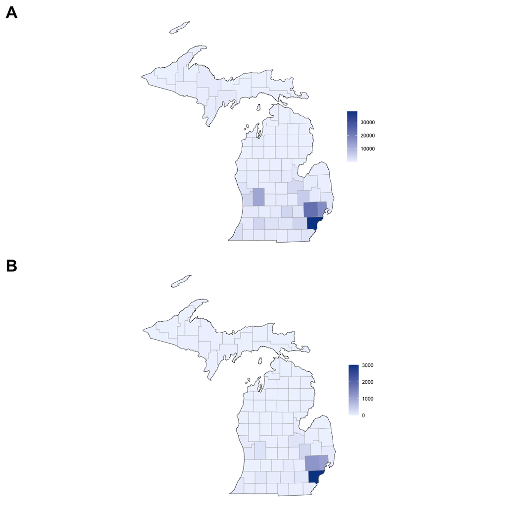

**Figure 1:** State-wide distribution of COVID-19. Panel A shows total cases, while panel B shows total deaths.

**Table1:** Total number of COVID-19 cases and deaths in metopolitan Detroit (Wayne, Oakland, and Macomb counties) vs all other Michigan counties combined.

| Detroit | Total.Cases | Total.Deaths |
| --- | --- | --- |
| No | 76,853 | 1,949 |
| Yes | 77,947 | 5,307 |

The three-county metropolitan Detroit area accounted for 77,947 out of 154,800 total cases in Michigan (50.4%). Metropolitan Detroit also represented 5,307 out of 7,256 total COVID-19 deaths in Michigan (73.1%).

But wait, you say, don’t most people live in those counties? Well… not *most*, but quite a few; let’s normalize the cases and deaths by county population and try that again.

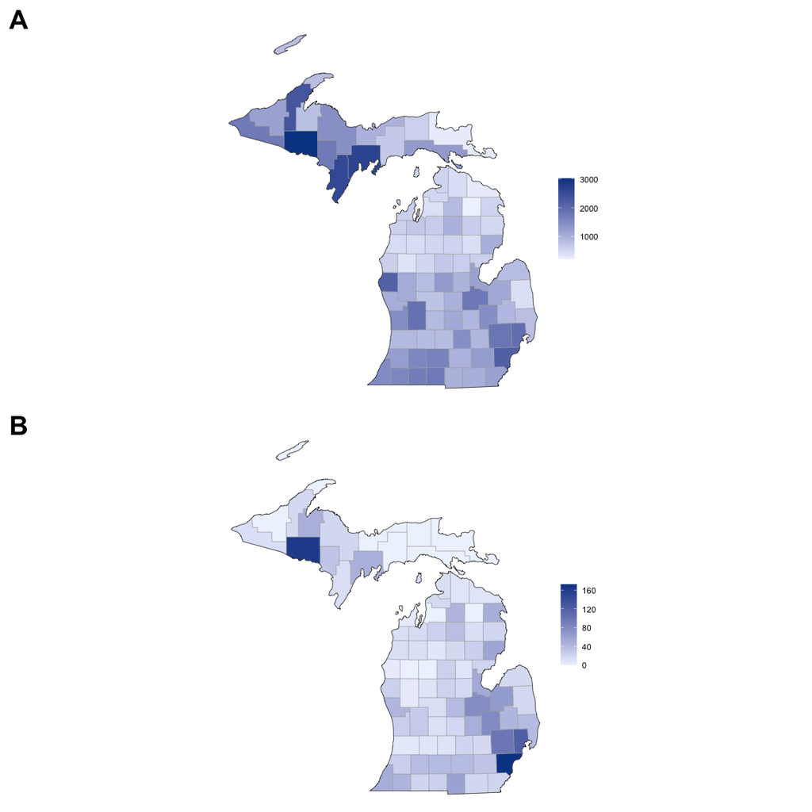

**Figure 2:** State-wide distribution of COVID-19 normalized for county population. Panel A shows total cases per 100,000 people, while panel B shows total deaths per 100,000 people.

**Table2:** Total number of COVID-19 cases and deaths per 100,000 people in metopolitan Detroit (Wayne, Oakland, and Macomb counties) vs all other Michigan counties combined.

| Detroit | Mean.Cases | SD.Cases | Mean.Deaths | SD.Deaths |
| --- | --- | --- | --- | --- |
| No | 1,027 | 575 | 24 | 24 |
| Yes | 1,975 | 181 | 130 | 38 |

After normalizing for county population, metropolitan Detroit counties average 1.9-times more COVID-19 cases and 5.4-times more COVID-19 deaths than the rest of Michigan counties. On average, metropolitan Detroit (m = 130.3) experienced significantly higher rates of COVID-19 deaths per 100,000 people than the rest of the state (m = 24.2), *t*(2.06) = -4.76, *p* < 0.039.

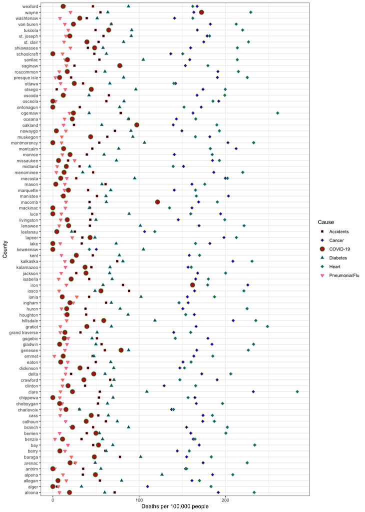

**Figure 3:** Normalized COVID-19 death rates by county (deaths per 100,000 people). The symbols indicate the mortality rates by various causes for each county.

Figure 3 highlights the fact that deaths per capita is not equal across all counties. Seven counties (including the Detroit metropolitan area) and much higher. Nearly three dozen counties have normalized COVID-19 death rates lower than that of car fatalities in the state. A total of 7,256 people have died of COVID-19 out of a population of 9,995,911 people. That gives a normalized value of 72.6 people per 100,000.

## Detroit vs everyone else

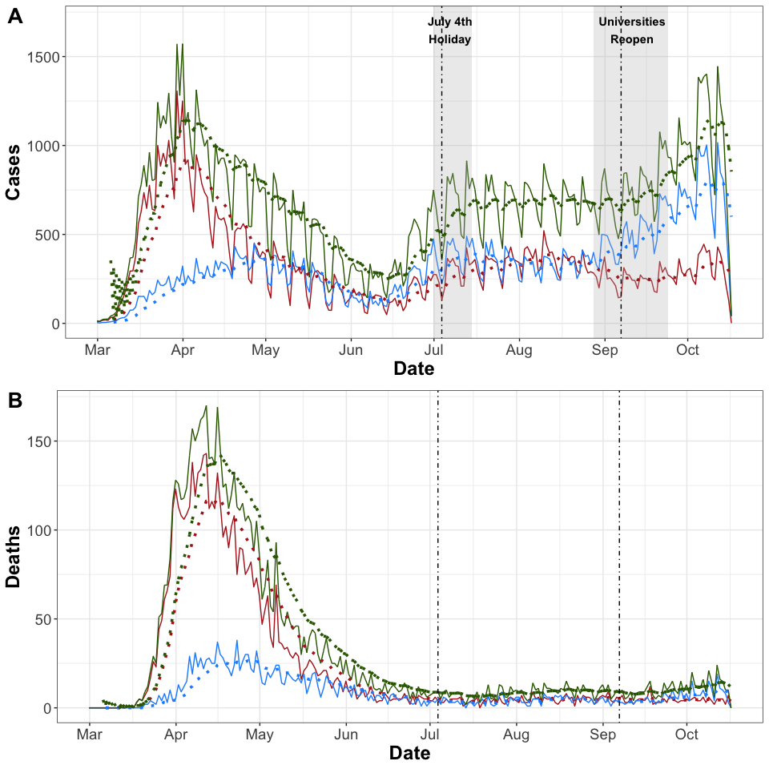

**Figure 4:** A comparison of COVID-19 incidence between metropolitan Detroit (red) and the rest of Michigan (blue). The total state numbers are shown in green. Seven-day moving averages of the data are shown as dotted lines. The veritcal lines denote holidays: The 4th of July and Labor Day on September 7th.

## Comparing Isabella (Central Michigan University), Mecosta (Ferris State University) and Ottawa (Grand Valley State University) county cases

Finally, I am also interested in comparing how Ferris State University does in controlling COVID-19 compared to Central Michigan University and Grand Valley State University. Figure 5 compares the total number of COVID-19 cases between those three counties.

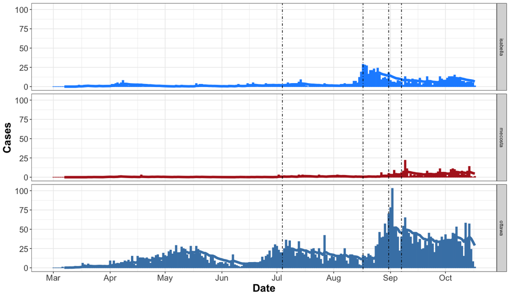

**Figure 5:** A comparison of the number of total cases in Isabella, Mecosta, and Ottawa counties. The bars indicate total daily cases and the lines are seven-day moving averages. The vertical lines indicate the fourth of July, CMU opening on August 17th, and GVSU and FSU opening on August 31st, and Labor Day on September 7th.

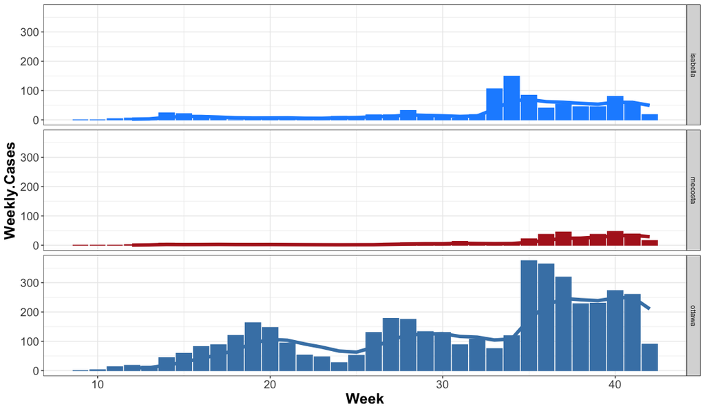

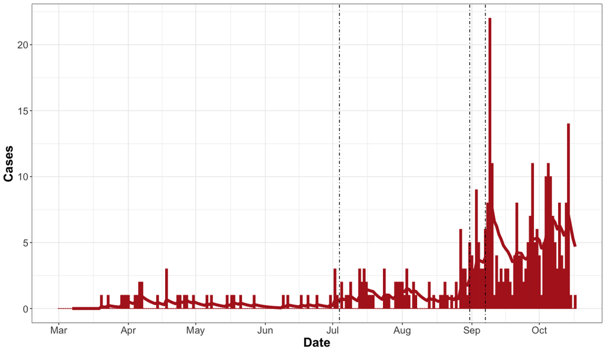

**Figure 7:** Mecosta cases (which includes Ferris State University). The bars indicate total daily cases and the lines are seven-day moving averages. The vertical lines indicate the fourth of July, FSU opening on August 31st, and Labor Day.

For comparision sake, here are the numbers of positive COVID-19 cases being reported on the [Ferris COVID dashboard page](https://www.ferris.edu/HTMLS/news/coronavirus/covid-19-dashboard.htm).

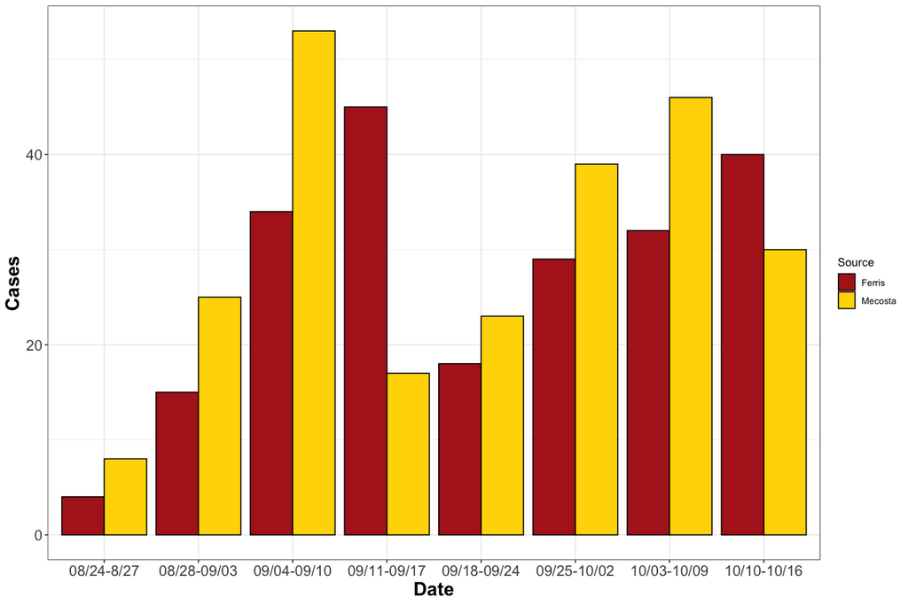

**Figure 8:** Total number of COVID-19 cases. Ferris reports its numbers every Thursday and began collecting data on August 21. The state-reported numbers for Mecosta county are shown for the same intervals.

As of September 17, Ferris State accounts for the vast majority of all reported cases in Mecosta county. There does not yet appear to be a community-associated outbreak at this point. The Mecosta county numbers often take several days to get processed and reported. It is sort of weird, though, that the Ferris numbers no longer seem to be reflected in the county data. We will see if the numbers now begin to decline or if COVID-19 moves from campus out into the general population.

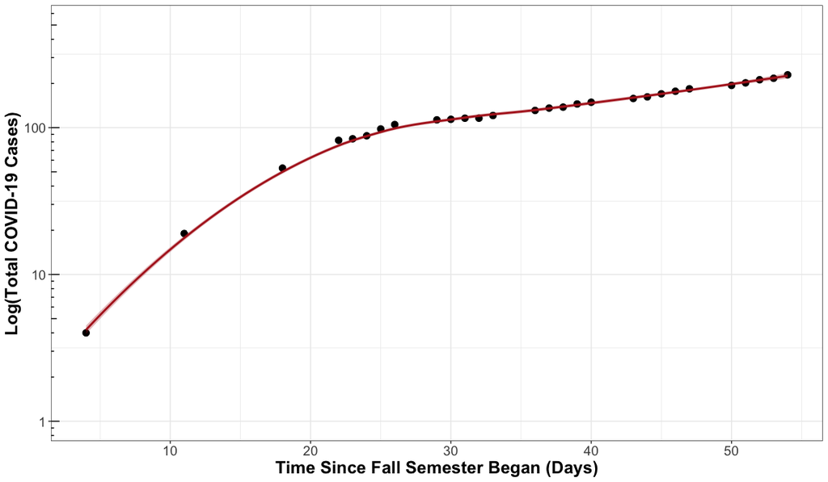

**Figure 9:** Total COVID-19 cases at Ferris State University since the beginning of the fall semester.

There appears to have been an exponential increase of COVID-19 cases on campus for the first few weeks of classes. A few positive students caused an initial outbreak within the dorms. The past few days seems to show a little slower spread. Perhaps we are beginning to bend the curve a bit - time will tell.